# Tarea 3

Arqueología Cuantitativa

Esteban Arroyo

10-10-2022

## Primero Definimos nuestra carpeta de trabajo

```r
setwd("C:/Users/usuario/Desktop/Arqueología Cuantitativa/Tareas/Tarea3")
```

## Cargamos nuestra librería y cargamos la base de datos

```r
library("readxl")
data_set<-read_excel("BD1_Trabajos_2022.xlsx", sheet="Hoja1")
```

## Hacemos un preview de nuestros datos

```r
head(data_set)
```

```
## # A tibble: 6 x 15
##   Sitio Capa  Cuadrícula Nivel `Largo morfológ~ Conservación Mat.prima `F. Base`
##   <chr> <chr> <chr>      <chr> <chr>            <chr>        <chr>     <chr>
## 1 Tu-58 1     A5/SW      3     11.41            Completa     Silíceas  Lasca
## 2 Tu-58 2     A6/SW      2     12.15            Completa     Silíceas  Lámina
## 3 Tu-58 3     A5/SW      13-17 13.08            Completa     Silíceas  Lasca
## 4 Tu-58 1     A5/SW      5     13.1             Completa     Obsidiana Frag.bif~
## 5 Tu-58 3     B5/SW      20    14.14            Completa     Silíceas  Lámina
## 6 Tu-58 3     A6/SW      17    15.35            Frac.distal  Silíceas  Lasca
## # ... with 7 more variables: Corteza <chr>, T. Talón <chr>, Tecnología <chr>,
## #   Extensión borde activo <chr>, Simetría del borde <chr>,
## #   Categoría morfofuncional <chr>, Tipos <chr>
```

### Ahora vemos el tipo de variable que tenemos

```r
str(data_set)
```

```
## tibble [612 x 15] (S3: tbl_df/tbl/data.frame)
##  $ Sitio                   : chr [1:612] "Tu-58" "Tu-58" "Tu-58" "Tu-58" ...
##  $ Capa                    : chr [1:612] "1" "2" "3" "1" ...
##  $ Cuadrícula              : chr [1:612] "A5/SW" "A6/SW" "A5/SW" "A5/SW" ...
##  $ Nivel                   : chr [1:612] "3" "2" "13-17" "5" ...
##  $ Largo morfológico       : chr [1:612] "11.41" "12.15" "13.08" "13.1" ...
##  $ Conservación            : chr [1:612] "Completa" "Completa" "Completa" "Completa" ...
##  $ Mat.prima               : chr [1:612] "Silíceas" "Silíceas" "Silíceas" "Obsidiana" ...
##  $ F. Base                 : chr [1:612] "Lasca" "Lámina" "Lasca" "Frag.bifaz" ...
##  $ Corteza                 : chr [1:612] "0%" "0%" "0%" "0%" ...
##  $ T. Talón                : chr [1:612] "ND" "ND" "Facetado" "nd" ...
##  $ Tecnología              : chr [1:612] "Monofacial marginal" "Bifacial extendido" "Bifacial extendido" "nd" ...
##  $ Extensión borde activo  : chr [1:612] "Largo" "Corto" "Largo" "nd" ...
##  $ Simetría del borde      : chr [1:612] "Asimétrico" "Simétrico" "Simétrico" "nd" ...
##  $ Categoría morfofuncional: chr [1:612] "Perforadores" "Perforadores" "Perforadores" "Núcleos" ...
##  $ Tipos                   : chr [1:612] NA NA NA "Bipolar" ...
```

## **Ejercicio 1**

### Nos interesa saber si existen diferencias significativas en el largo morfológico de los instrumentos de las distintas materias primas (excluya granito y otras, así como las piezas no completas). Para lo anterior, efectúe lo siguiente:

### a) Desarrolle estadística descriptiva gráfica para examinar las diferencias (gráfico de caja y bigote)

### Primero haremos el trabajo de pre-procesamiento de la variable largo morfológico para eliminar los “nd” y convertirla en númerica

### En primer lugar contamos cuantos valores son iguales a “nd”

```r
sum (data_set$`Largo morfológico` == "nd")
```

```
## [1] 325
```

#### Imputar valores “nd” de la columna Largo morfológico como NA para facilitar el trabajo

```r
data_set$`Largo morfológico`[data_set$`Largo morfológico`=="nd"] <- NA
```

### Contar los NA en Largo mofologico

```r
sum(is.na(data_set$`Largo morfológico`))
```

```
## [1] 325
```

### Convertir la columna Largo morfológico en numerica para que lo leea correctamente

```r
data_set$`Largo morfológico` <- as.numeric(data_set$`Largo morfológico`)
```

### Verificamos que la columna sea numérica

```r
str(data_set$`Largo morfológico`)
```

```
##  num [1:612] 11.4 12.2 13.1 13.1 14.1 ...
```

### Generamos una nueva base solo con las columnas que necesito

```r
library(dplyr)
data_set_mod1 <- select(data_set, c("Conservación", "Mat.prima", `Largo morfológico`))
```

### Luego eliminamos todo lo que no sea Conservación == “Completa”

```r
data_set_mod1 <- data_set_mod1[data_set_mod1$Conservación =="Completa",]
```

### Verificamos los cambios

```r
table(data_set_mod1$Conservación)
```

```
##
## Completa
##      288
```

### Ahora eliminamos los NA de la nueva base

```r
data_set_mod1 <- na.omit(data_set_mod1)
```

### Verificamos que no existan NA en toda nuestra nueva base data_set_mod1

```r
sum(is.na(data_set_mod1))
```

```
## [1] 0
```

### Verificamos los cambios

```r
table(data_set_mod1$Conservación)
```

```
##
## Completa
##      274
```

### Ahora eliminamos solo granito y otras de Mat.primas

```r
data_set_mod1 <- data_set_mod1[data_set_mod1$Mat.prima !="Granito",]
data_set_mod1 <- data_set_mod1[data_set_mod1$Mat.prima !="Otras",]
```

### Nuestra base final es de 273 observaciones

```r
table(data_set_mod1$Conservación)
```

```
##
## Completa
##      273
```

### Ahora hacemos el gráfico

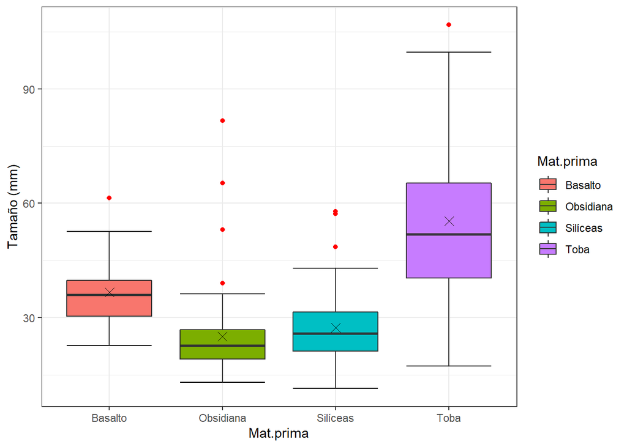

```r
library(ggplot2)
ggplot(data_set_mod1, aes(x=Mat.prima, y= `Largo morfológico` )) + stat_boxplot(geom="errorbar")  + geom_boxplot(aes(fill=Mat.prima), outlier.colour = "red") + stat_summary(fun=mean,geom="point",shape=4,size=3) + theme_bw() + ylab("Tamaño (mm)")
```

### Ahora hacemos las estadísticas descriptivas

```r
library(psych)
estadisticas <- describeBy(data_set_mod1$`Largo morfológico`, data_set_mod1$Mat.prima, mat = TRUE, data = data_set_mod1)
```

### Llamamos las librerías para visualizar mejor nuestras tablas

```r
library("janitor")
library("flextable")
library(dplyr)
```

### Vemos la tabla usando el flextable y le hacemos los adornos respectivos

```r
estadisticas %>% flextable() %>% set_caption("Tabla Descriptivas") %>% bg(bg="#28B463", part = "header") %>% color(color = "white", part = "header") %>% autofit()
```

Tabla Descriptivas

| item | group1 | vars | n | mean | sd | median | trimmed | mad | min | max | range | skew | kurtosis | se |
| --- | --- | --- | --- | --- | --- | --- | --- | --- | --- | --- | --- | --- | --- | --- |
| 1 | Basalto | 1 | 44 | 36.63636 | 8.100097 | 35.975 | 35.85361 | 8.376690 | 22.73 | 61.40 | 38.67 | 0.8793954 | 0.5475562 | 1.2211356 |
| 2 | Obsidiana | 1 | 68 | 25.12456 | 10.735597 | 22.750 | 23.26643 | 5.596815 | 13.10 | 81.69 | 68.59 | 3.1428017 | 12.0788990 | 1.3018824 |
| 3 | Silíceas | 1 | 85 | 27.42082 | 8.945755 | 25.830 | 26.71304 | 7.605738 | 11.41 | 57.90 | 46.49 | 0.9838061 | 1.4487390 | 0.9703034 |
| 4 | Toba | 1 | 76 | 55.30026 | 20.839411 | 51.900 | 54.40661 | 19.347930 | 17.28 | 106.80 | 89.52 | 0.4355462 | -0.4374586 | 2.3904444 |

### b) Plantee la hipótesis nula y alternativa

## Ho: No hay diferencia entre el promedio del Largo Mofológico por Materia Prima en Conservación Completa

## Hi: Sí hay diferencia entre el promedio del Largo Mofológico por Materia Prima en Conservación Completa

### c) Compruebe los supuestos para pruebas paramétricas (y aplique transformaciones si le aparece necesario)

### Instalamos los paquetes necesarios

```r
library(nortest)
library(rcompanion)
library(car)
```

### Para aplicar los test de normalidad tenemos que hacer sub grupos por Materias Primas

```r
bas <- subset(data_set_mod1, Mat.prima=="Basalto")
obs <- subset(data_set_mod1, Mat.prima=="Obsidiana")
sil <- subset(data_set_mod1, Mat.prima=="Silíceas")
tob <- subset(data_set_mod1, Mat.prima=="Toba")
```

### Ahora aplicamos los test de normalidad a cada subgrupo

```r
lillie.test(bas$`Largo morfológico`)
```

```
##
##  Lilliefors (Kolmogorov-Smirnov) normality test
##
## data:  bas$`Largo morfológico`
## D = 0.13051, p-value = 0.05783
```

```r
lillie.test(obs$`Largo morfológico`)
```

```
##
##  Lilliefors (Kolmogorov-Smirnov) normality test
##
## data:  obs$`Largo morfológico`
## D = 0.21019, p-value = 6.114e-08
```

```r
lillie.test(sil$`Largo morfológico`)
```

```
##
##  Lilliefors (Kolmogorov-Smirnov) normality test
##
## data:  sil$`Largo morfológico`
## D = 0.085719, p-value = 0.1284
```

```r
lillie.test(tob$`Largo morfológico`)
```

```
##
##  Lilliefors (Kolmogorov-Smirnov) normality test
##
## data:  tob$`Largo morfológico`
## D = 0.11033, p-value = 0.02285
```

### Podemos observar que el Largo morfológico en **Obsidiana** y **Toba** no se ajustan a la Normal

### Por tanto hacemos unas transformaciones y volvemos a probar el test

### hacemos el grafico para visualizar la forma de la distribución

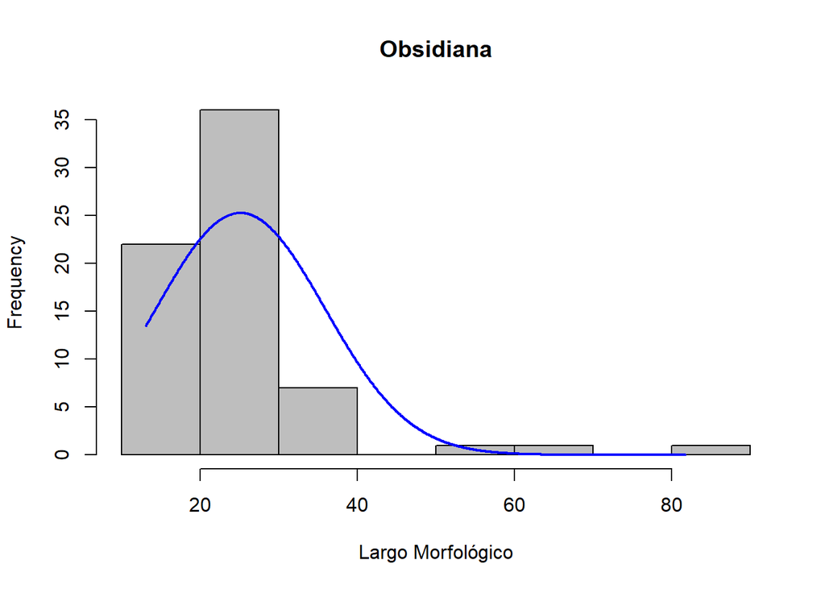

```r
plotNormalHistogram(obs$`Largo morfológico`, main = "Obsidiana", xlab="Largo Morfológico")
```

### Hacemos las transformación. Hicimos previemante la transformación con sqrt() y log() pero no fué suficiente

```r
lillie.test(1/(obs$`Largo morfológico`))
```

```
##
##  Lilliefors (Kolmogorov-Smirnov) normality test
##
## data:  1/(obs$`Largo morfológico`)
## D = 0.059767, p-value = 0.792
```

### Volvemos hacer el gráfico para observar el ajuste de la distribución

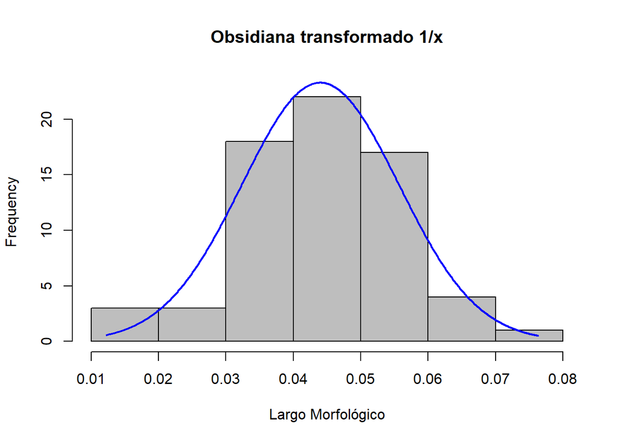

```r
plotNormalHistogram(1/(obs$`Largo morfológico`), main = "Obsidiana transformado 1/x", xlab="Largo Morfológico")
```

### Ahora Visualizamos la distribución de Toba

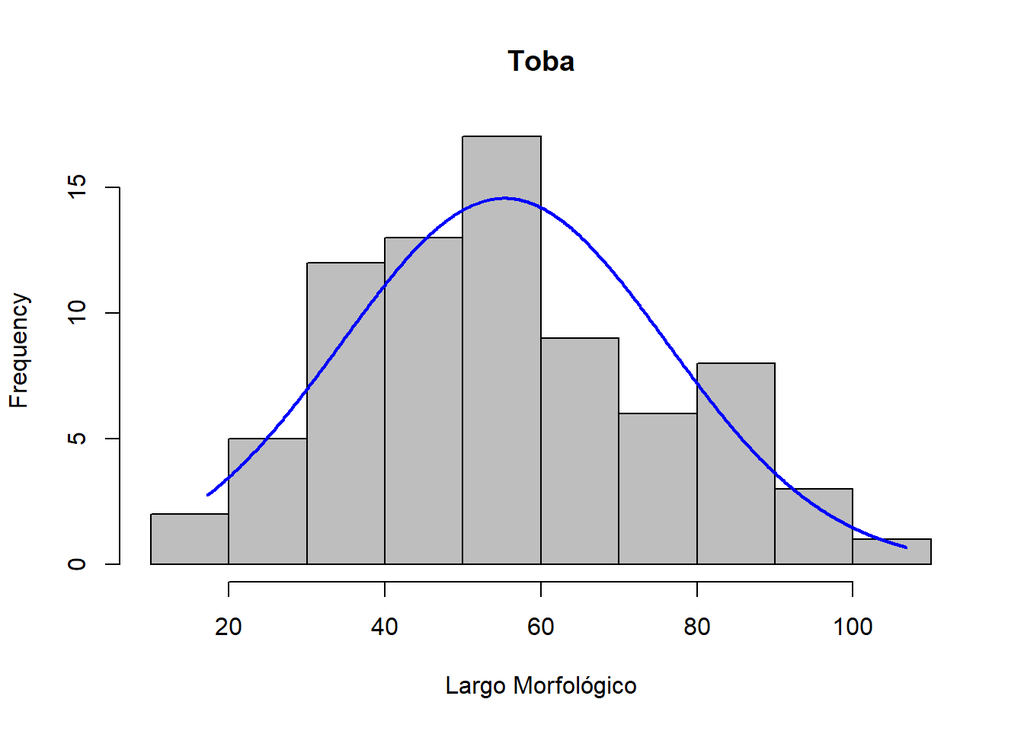

```r
plotNormalHistogram(tob$`Largo morfológico`, main = "Toba", xlab="Largo Morfológico")
```

### Ahora hacemos el mismo ajuste para el resto de los subgrupos

```r
lillie.test(1/(tob$`Largo morfológico`))
```

```
##
##  Lilliefors (Kolmogorov-Smirnov) normality test
##
## data:  1/(tob$`Largo morfológico`)
## D = 0.18567, p-value = 7.561e-07
```

### Vemos que no se ajusta a la normal con la transformación de 1/x por tanto, pordemos concluir que los subgrupos no permiten la misma transformación, por tanto no podemos asumir que todos los grupos de ajustan a la normal y por ende no podemos usar el **Test ANOVA**

### e) Efectúe la prueba estadística que mejor se adecúe al caso y saque las conclusiones que competan (incluya y comente pruebas pos-hoc si es que el caso lo permite)

### En este caso vamos usar el **Test de Kruskal-Wallis**, que es la versión no-parametrica del **ANOVA**

```r
kruskal.test(`Largo morfológico`~Mat.prima, data=data_set_mod1)
```

```
##
##  Kruskal-Wallis rank sum test
##
## data:  Largo morfológico by Mat.prima
## Kruskal-Wallis chi-squared = 131.04, df = 3, p-value < 2.2e-16
```

### **CONCLUSIÓN** Se rechaza la Ho de igualdad de promedios muestrales de Largo morfológico para los 4 grupos de materias primas.

### Podemos hacer una salida de Kruskal-Wallis más bonita con flextable

```r
kruskal.test(`Largo morfológico`~Mat.prima, data=data_set_mod1) %>% as_flextable() %>%
  set_caption("Contraste No paramétrico de Kruskal-Wallis") %>% bg(bg="#A04000", part = "header") %>% color(color = "white", part = "header") %>% autofit()
```

Contraste No paramétrico de Kruskal-Wallis

| statistic | p.value | parameter | method |
| --- | --- | --- | --- |
| 131.0 | 0.0000*** | 3 | Kruskal-Wallis rank sum test |

Signif. codes: 0 <= '***' < 0.001 < '**' < 0.01 < '*' < 0.05

## **Ejercicio 2**

## Nos interesa saber si existen diferencias significativas entre el largo morfológico de perforadores y puntas de proyectil (excluya las piezas no completas). Para lo anterior, efectúe lo siguiente:

### a) Desarrolle estadística descriptiva gráfica para examinar las diferencias (gráfico de caja y bigote)

### Generamos una nueva base solo con las columnas que necesito

```r
data_set_mod2 <- select(data_set, c("Conservación", `Categoría morfofuncional`, `Largo morfológico`))
```

### Luego eliminamos todo lo que no sea Conservación == “Completa”

```r
data_set_mod2 <- data_set_mod2[data_set_mod2$Conservación =="Completa",]
```

### Verificamos los cambios

```r
table(data_set_mod2$Conservación)
```

```
##
## Completa
##      288
```

### Verificamos la existencia de NA en la nueva base

```r
sum(is.na(data_set_mod2))
```

```
## [1] 14
```

### Ahora eliminamos los NA de la nueva base

```r
data_set_mod2 <- na.omit(data_set_mod2)
```

### Verificamos que no existan NA en toda nuestra nueva base data_set_mod2

```r
sum(is.na(data_set_mod2))
```

```
## [1] 0
```

### Ahora eliminamos todo lo que no sea perforadores y puntas de proyectil

```r
data_set_mod2 <- data_set_mod2[data_set_mod2$`Categoría morfofuncional` =="Perforadores" | data_set_mod2$`Categoría morfofuncional` =="Puntas de proyectil",]
```

### Verificamos ajustes

```r
table(data_set_mod2$`Categoría morfofuncional`)
```

```
##
##        Perforadores Puntas de proyectil
##                  56                  62
```

### Por tanto la nueva base es de **118** Observaciones

```r
table(data_set_mod2$Conservación)
```

```
##
## Completa
##      118
```

### Ahora hacemos el gráfico

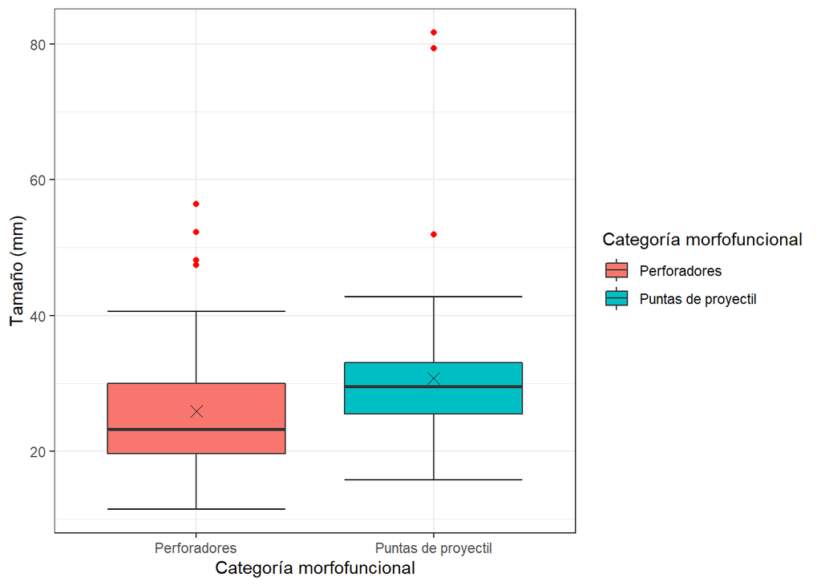

```r
ggplot(data_set_mod2, aes(x=`Categoría morfofuncional`, y= `Largo morfológico` )) + stat_boxplot(geom="errorbar")  + geom_boxplot(aes(fill=`Categoría morfofuncional`), outlier.colour = "red") + stat_summary(fun=mean,geom="point",shape=4,size=3) + theme_bw() + ylab("Tamaño (mm)")
```

### Ahora hacemos las estadísticas descriptivas

```r
estadisticas2 <- describeBy(data_set_mod2$`Largo morfológico`, data_set_mod2$`Categoría morfofuncional`, mat = TRUE)
```

### Vemos la tabla usando el flextable y le hacemos los adornos respectivos

```r
estadisticas2 %>% flextable() %>% set_caption("Tabla Descriptivas2") %>% bg(bg="#28B463", part = "header") %>% color(color = "white", part = "header") %>% autofit()
```

Tabla Descriptivas2

| item | group1 | vars | n | mean | sd | median | trimmed | mad | min | max | range | skew | kurtosis | se |
| --- | --- | --- | --- | --- | --- | --- | --- | --- | --- | --- | --- | --- | --- | --- |
| 1 | Perforadores | 1 | 56 | 25.85875 | 9.825918 | 23.210 | 24.69717 | 6.634635 | 11.41 | 56.39 | 44.98 | 1.196072 | 1.10157 | 1.313044 |
| 2 | Puntas de proyectil | 1 | 62 | 30.74661 | 11.145500 | 29.515 | 29.29520 | 5.700597 | 15.80 | 81.69 | 65.89 | 2.831177 | 10.33983 | 1.415480 |

### b) Plantee la hipótesis nula y alternativa

## Ho: No hay diferencia entre el promedio del Largo Mofológico por Categoría morfofuncional en Conservación Completa

## Hi: Sí hay diferencia entre el promedio del Largo Mofológico por Categoría morfofuncional en Conservación Completa

### c) Compruebe los supuestos para pruebas paramétricas (y aplique transformaciones si le aparece necesario)

### Para aplicar los test de normalidad tenemos que hacer sub grupos por Categoría morfofuncional

```r
per <- subset(data_set_mod2, `Categoría morfofuncional`=="Perforadores")
pun <- subset(data_set_mod2, `Categoría morfofuncional`=="Puntas de proyectil")
```

### Ahora aplicamos los test de normalidad a cada subgrupo

```r
lillie.test(per$`Largo morfológico`)
```

```
##
##  Lilliefors (Kolmogorov-Smirnov) normality test
##
## data:  per$`Largo morfológico`
## D = 0.19232, p-value = 2.06e-05
```

```r
lillie.test(pun$`Largo morfológico`)
```

```
##
##  Lilliefors (Kolmogorov-Smirnov) normality test
##
## data:  pun$`Largo morfológico`
## D = 0.19798, p-value = 2.254e-06
```

### Como ambos rechazan el ajuste a la normal, hay que hacer transformaciones para ver si se pueden ajustar

### hacemos un Histograma para visualizar la forma de la distribución

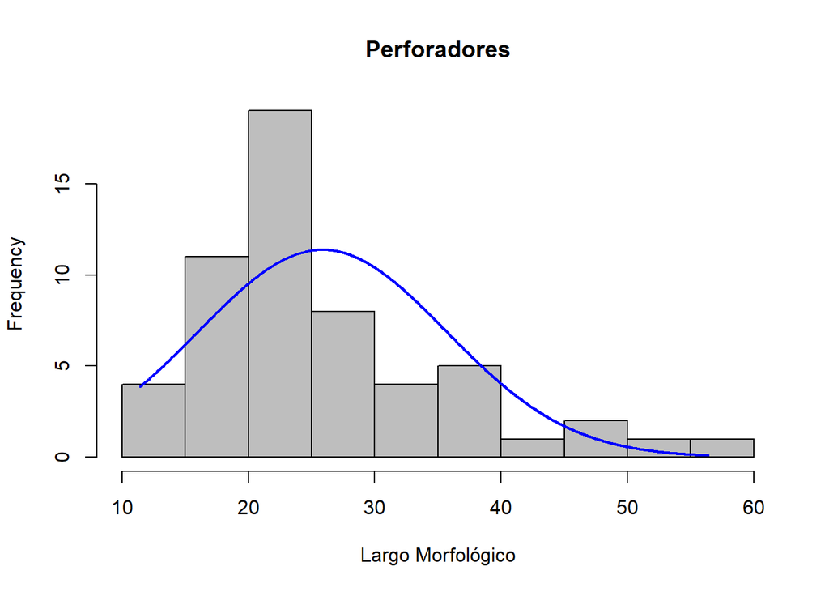

```r
plotNormalHistogram(per$`Largo morfológico`, main = "Perforadores", xlab="Largo Morfológico")
```

### Luego hacemos la transformación respectiva y probamos el ajuste

```r
lillie.test(1/(per$`Largo morfológico`))
```

```
##
##  Lilliefors (Kolmogorov-Smirnov) normality test
##
## data:  1/(per$`Largo morfológico`)
## D = 0.085412, p-value = 0.3921
```

### Ahora hacemos nuevamente el gráfico para ver el ajuste

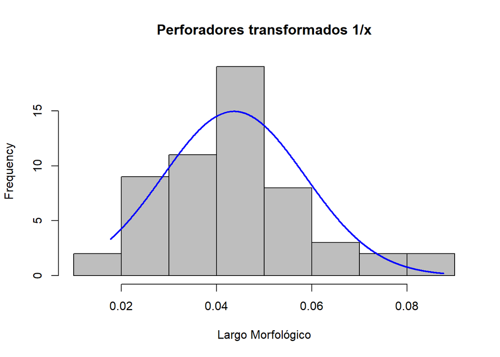

```r
plotNormalHistogram(1/(per$`Largo morfológico`), main = "Perforadores transformados 1/x", xlab="Largo Morfológico")
```

### Ahora probamos la transformación en el grupo de Puntas de proyectil

```r
lillie.test(1/(pun$`Largo morfológico`))
```

```
##
##  Lilliefors (Kolmogorov-Smirnov) normality test
##
## data:  1/(pun$`Largo morfológico`)
## D = 0.10743, p-value = 0.07253
```

### Como vemos que tambien se ajusta, lo graficamos. Antes de la transformación

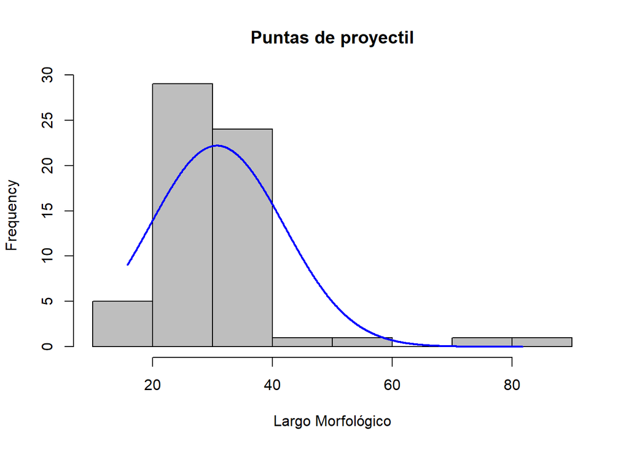

```r
plotNormalHistogram(pun$`Largo morfológico`, main = "Puntas de proyectil", xlab="Largo Morfológico")
```

### Despues de la Transformación

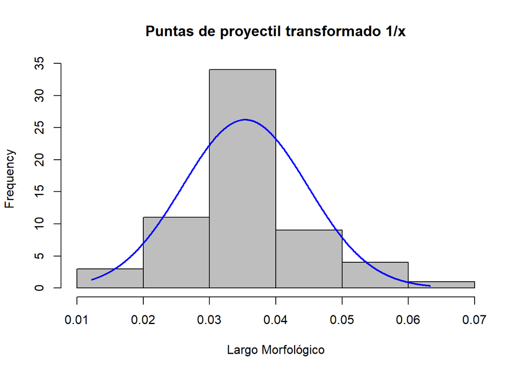

```r
plotNormalHistogram(1/(pun$`Largo morfológico`), main = "Puntas de proyectil transformado 1/x", xlab="Largo Morfológico")
```

### Ahora efectuamos la transformación en la base para poder aplicar el test

```r
data_set_mod2$Largo_morf_trans <- 1/(data_set_mod2$`Largo morfológico`)
```

### d) Efectúe la prueba estadística que mejor se adecúe al caso y saque las conclusiones que competan

### Aplicamos el test de Levene para evaluar homogeneidad de Varianzas

```r
leveneTest(data_set_mod2$Largo_morf_trans, as.factor(data_set_mod2$`Categoría morfofuncional`))
```

```
## Levene's Test for Homogeneity of Variance (center = median)
##        Df F value   Pr(>F)
## group   1  7.9064 0.005786 **
##       116
## ---
## Signif. codes:  0 '***' 0.001 '**' 0.01 '*' 0.05 '.' 0.1 ' ' 1
```

### Como la prueba de Levene fué rechazada, debemos asumir varianzas diferentes o desiguales para usar la T-test., por lo que hay que especificar en los argumentos var.equal=F

```r
t.test(data_set_mod2$Largo_morf_trans~data_set_mod2$`Categoría morfofuncional`, var.equal=F)
```

```
##
##  Welch Two Sample t-test
##
## data:  data_set_mod2$Largo_morf_trans by data_set_mod2$`Categoría morfofuncional`
## t = 3.5573, df = 91.062, p-value = 0.0005972
## alternative hypothesis: true difference in means between group Perforadores and group Puntas de proyectil is not equal to 0
## 95 percent confidence interval:
##  0.00366014 0.01291614
## sample estimates:
##        mean in group Perforadores mean in group Puntas de proyectil
##                        0.04366901                        0.03538087
```

### **CONCLUSIÓN** En este caso se rechaza la Ho de no diferencia entre el promedio del Largo Mofológico por Categoría morfofuncional en Conservación Completa si se asume la Hi

### Podemos hacer una salida de t-test más bonita con flextable

```r
t.test(data_set_mod2$Largo_morf_trans~data_set_mod2$`Categoría morfofuncional`, var.equal=F) %>% as_flextable() %>% set_caption("Contraste Paramétrico de t-test con ajuste de Welch") %>% bg(bg="#D4AC0D", part = "header") %>% color(color = "white", part = "header") %>% autofit()
```

Contraste Paramétrico de t-test con ajuste de Welch

| estimate | estimate1 | estimate2 | statistic | p.value | parameter | conf.low | conf.high | method | alternative |
| --- | --- | --- | --- | --- | --- | --- | --- | --- | --- |
| 0.0 | 0.0 | 0.0 | 3.6 | 0.0006*** | 91.1 | 0.0 | 0.0 | Welch Two Sample t-test | two.sided |

Signif. codes: 0 <= '***' < 0.001 < '**' < 0.01 < '*' < 0.05